# Final Report

## Adaboost

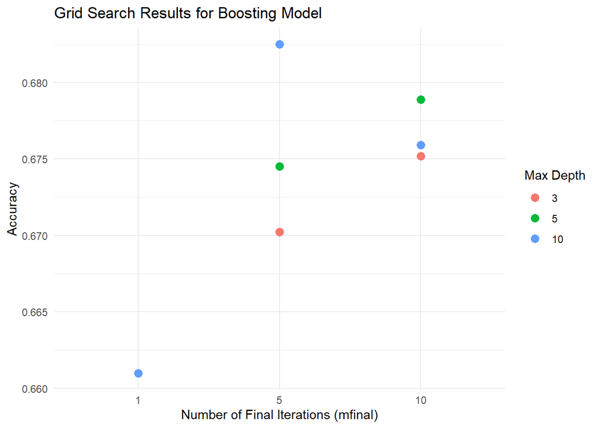

```r
param_grid <- expand.grid(mfinal = c(1, 5, 10),maxdepth = c(3, 5, 10))
control <- trainControl(method = "cv", number = 3)
train_model <- function(data, mfinal, maxdepth) {model <- boosting(y ~ ., data = data,boos = TRUE,mfinal = mfinal,control = rpart.control(maxdepth = maxdepth)); return(model)}
evaluate_model <- function(model, data) {pred <- predict.boosting(model, newdata = data)
accuracy <- sum(pred$class == data$y) / nrow(data); return(accuracy)}
best_model <- NULL
best_accuracy <- 0
results <- data.frame()
for (i in 1:nrow(param_grid)) {
  params <- param_grid[i, ];accuracy_list <- c()
  for (fold in 1:control$number) {
    set.seed(fold)
    trainIndex <- createDataPartition(train$y, p = .8, list = FALSE, times = 1)
    train_fold <- train[trainIndex,]
    test_fold <- train[-trainIndex,]
    model <- train_model(train_fold, params$mfinal, params$maxdepth)
    accuracy <- evaluate_model(model, test_fold)
    accuracy_list <- c(accuracy_list, accuracy)
  }
  avg_accuracy <- mean(accuracy_list)
  results <- rbind(results, cbind(params, accuracy = avg_accuracy))
  if (avg_accuracy > best_accuracy) {
    best_accuracy <- avg_accuracy
    best_model <- train_model(train, params$mfinal, params$maxdepth)
  }
}
results$mfinal <- as.factor(results$mfinal)
results$maxdepth <- as.factor(results$maxdepth)
ggplot(results, aes(x = mfinal, y = accuracy, color = maxdepth)) +
  geom_point(size = 3) +
  labs(title = "Grid Search Results for Boosting Model",
       x = "Number of Final Iterations (mfinal)",
       y = "Accuracy",
       color = "Max Depth") +
  theme_minimal()
```

```r
print(paste("Best Accuracy: ", round(best_accuracy * 100, 2), "%", sep = ""))
```

```
## [1] "Best Accuracy: 68.25%"
```

A parameter grid was defined, containing the number of base classifiers (decision trees) ‘mfinal’, ranging from (1, 5, 10), and the maximum depth of the decision tree ‘maxdepth’, also ranging from (3, 5, 10). The model was then trained and evaluated for each parameter combination using 3-fold cross-validation. The accuracy of each cross-validation was recorded and averaged. We used the boosting() function to build the AdaBoost model.

## AdaBoost Result

```r
model_ada <- boosting(y ~ ., data = train, boos = TRUE, mfinal = 5, control = rpart.control(maxdepth = 10))
pred <- predict.boosting(model_ada, newdata = test)
pred_class <- pred$class
actual_class <- test$y
confusion_mtx <- confusionMatrix(factor(pred_class), factor(actual_class))
```

```r
cm <- as.data.frame.table(confusion_mtx$table)
colnames(cm) <- c("True", "Predicted", "Freq")
```

## Random Forest

```r
library(randomForest)
```

```r
train_control <- trainControl(method = "cv", number = 5)
set.seed(123)
model_rf <- train(y ~ .,data = train,method = "rf",trControl = train_control,tuneLength = 5)
```

Subsequently, we constructed a random forest model employing 5-fold cross-validation. The algorithm was automatically tuned with a ‘tuneLength = 5’, indicating that the model iterated over 5 different ‘mtry’ values to determine the optimal selection, while ‘mtry’ explaining the number of variables to randomly sample as candidates at each split. In this case, we specified “rf” to denote the random forest approach.